# [Christian Schluter’s] M2 project based on Lalive, van Ours, and Zweimuller (2006, ReStud): The Duration of Unemployment

[figure not shown]

This **assessed** homework (i.e. your research report) will contribute **50%** to your final grade for this course.

The submission consists of a printout of a **Notebook** (such as a Rstudio or Jupyter notebook), in which you combine discussions of questions as well as computations.

We will replicate some results documented in:

- Lalive, R. van Ours, J. and J. Zweimuller (2006), “How Changes in Financial Incentives Affect the Duration of Unemployment.” *The Review of Economic Studies*, 73, 4, 1009-1038.

# 1 Research objectives

- **Q1** What are the contributions of this study ?

Write a brief summary (no more than 1.5 pages) that discusses the contributions of this study. You might wish to consider the following questions: What are the objectives, and how do they relate to the established literature? What is novel about the empirical strategy? What are the results and how convincing are these?

# 2 Background

The authors seek to identify the causal effect of benefit duration on the willingness of individuals to accept jobs using a policy change that took place in Austria in 1989.

The policy affected various unemployed workers differently: a first group experienced an increase in RR (replacement rate); a second group experienced an extension of PBD (potential benefit duration); a third group experienced both changes; and a fourth group experienced no change (the control group).

The potential benefit duration was increased, depending on age and experience: For workers younger than 40 and who had little previous work experience, the potential benefit duration remained unchanged. For workers with high levels of previous work experience, the duration has increased.

# 3 Data Preparation

The data are provided in the data set `fi.dta`. This file, which contains 225,821 unemployment spells, is quite large (150 MB) as it also contains the interaction terms used in the PH model estimation.

```r
library(foreign)  ## for: read.dta
## do not use haven::read_dta since this messes up `udat$type` factor labels
library(tidyverse)

library(survival)

udat <- read.dta("data/fi.dta")
udat <- udat[,1:134] ## get rid of some superfluous variables
udat <- as_tibble(udat)

dim(udat)  ## N = 225,821
```

```
## [1] 225821    134
```

```r
glimpse(udat[,1:36])
```

```
## Rows: 225,821
## Columns: 36
## $ beginn   <dbl> 10412, 10169, 10624, 10343, 10654, 10101, 10652, 10338, 10705…
## $ ein_zus  <dbl> 0, 0, 0, 0, 0, 0, 0, 0, 0, 0, 0, 0, 0, 0, 0, 0, 0, 0, 1, 0, 0…
## $ sfrau    <dbl> 0, 1, 1, 0, 0, 0, 1, 1, 1, 0, 0, 1, 1, 1, 1, 1, 1, 0, 1, 1, 0…
## $ age      <dbl> 51.13758, 54.71595, 54.04791, 54.11636, 46.13005, 42.11909, 5…
## $ after    <dbl> 0, 0, 0, 0, 0, 0, 0, 0, 0, 0, 0, 0, 0, 0, 0, 0, 0, 0, 0, 0, 0…
## $ dur      <dbl> 0.1428571, 0.1428571, 0.1428571, 0.1428571, 0.1428571, 0.1428…
## $ nwage_pj <dbl> 11282.729, 8577.623, 6828.051, 10071.884, 6342.333, 6094.196,…
## $ e3_5     <dbl> 1, 1, 1, 0, 1, 1, 1, 0, 1, 1, 1, 1, 1, 1, 1, 1, 1, 1, 1, 1, 1…
## $ bdur     <dbl> 30, 30, 30, 20, 30, 30, 30, 20, 30, 30, 30, 30, 30, 30, 30, 3…
## $ y1988    <dbl> 1, 0, 0, 1, 0, 0, 0, 1, 0, 1, 1, 0, 0, 1, 1, 1, 0, 1, 0, 1, 1…
## $ y1989    <dbl> 0, 0, 1, 0, 1, 0, 1, 0, 1, 0, 0, 0, 0, 0, 0, 0, 1, 0, 1, 0, 0…
## $ y1990    <dbl> 0, 0, 0, 0, 0, 0, 0, 0, 0, 0, 0, 0, 0, 0, 0, 0, 0, 0, 0, 0, 0…
## $ y1991    <dbl> 0, 0, 0, 0, 0, 0, 0, 0, 0, 0, 0, 0, 0, 0, 0, 0, 0, 0, 0, 0, 0…
```

[output cut: 23 more lines]

The groups are defined by the variable `type` which is coded as a factor (levels can be examined using `levels(udat$type)`).

```r
table(udat$type)
```

```
##
## PBD and RR        PBD         RR    control
##      21174      99404      32470      72773
```

The duration of interested is right censored at 104 weeks, $t_u ^{104} = \min \{t_u, 104 \}$, which we have to generate:

```r
## Computation of average spells when durations are truncated at 104 weeks
udat %>%
  mutate(dur104 = dur,
         dur104 = ifelse(dur104 > 104, 104, dur104)) ->
  udat
```

The exit indicator is `uncc`. The binary variable `after` indicates the period after the policy change.

The key variables and interaction terms contained in the data set code this design:

| variable name | description |
| --- | --- |
| dur | duration of unemployment spell (weeks) |
| bdur | potential benefit duration (weeks) |
| uncc | =1 if spell not censored |
| tr | =1 if replacement rate change |
| t39 | =1 if PBD 30-39 change |
| t52 | =1 if PBD 30-52 change |
| t39_tr | t39 * tr |
| t52_tr | t52 * tr |
| tr_a0 | tr * after0 |
| t39_a0 | t39 * after0 |
| t52_a0 | t52 * after0 |
| t39tra0 | t39 * tr * after0 |
| t52tra0 | t52 * tr * after0 |
| after | =1 if spell starts after Aug 1, 1989 |
| after0 | = 1 if interval 0 after Aug 1, 1989 |

# 4 Difference-in-Differences

The difference-in-differences estimator:

$$\begin{equation*}
\tilde{\Delta}_{DD}=\left( \bar{Y}_{A}^{T}-\bar{Y}_{B}^{T}\right) -\left( \bar{Y}_{A}^{C}-\bar{Y}_{B}^{C}\right)
\end{equation*}$$
where $\bar{Y}_{B}^{T}$ and $\bar{Y}_{A}^{T}$ are the average duration of unemployment for the treated group before and after the date of the reform. $\bar{Y}_{B}^{C}$ and $\bar{Y}_{A}^{C}$ are the average duration of unemployment for the control group before and after the reform

- **Q2** (difference-in-differences) Attempt to replicate Table 4 of the paper:

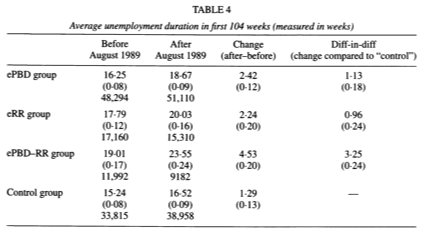

In my implementation, I get small differences.

For instance, computing manually the means for each group:

```
## # A tibble: 4 × 4
##       m     N     se group
##   <dbl> <int>  <dbl> <chr>
## 1  15.8 48294 0.0757 PBD before
## 2  18.1 51110 0.0912 PBD after
## 3  17.1 17160 0.118  RR before
## 4  19.1 15310 0.152  RR after
```

The following approach uses `pivot_longer` and `pivot_wider` to compute the differences. The result is rendered nicely using `kable`.

| type | name | 0 | 1 | diff | DiD |
| --- | --- | --- | --- | --- | --- |
| PBD and RR | mean | 18.49 | 22.74 | 4.25 | 3.08 |
| PBD and RR | sd | 0.16 | 0.23 | NA | NA |
| PBD and RR | N | 11992.00 | 9182.00 | NA | NA |
| PBD | mean | 15.83 | 18.08 | 2.25 | 1.08 |
| PBD | sd | 0.08 | 0.09 | NA | NA |
| PBD | N | 48294.00 | 51110.00 | NA | NA |
| RR | mean | 17.11 | 19.10 | 1.99 | 0.82 |
| RR | sd | 0.12 | 0.15 | NA | NA |
| RR | N | 17160.00 | 15310.00 | NA | NA |
| control | mean | 14.46 | 15.63 | 1.17 | 0.00 |
| control | sd | 0.08 | 0.09 | NA | NA |
| control | N | 33815.00 | 38958.00 | NA | NA |

Alternatively, using a regression implementation, and extracting the relevant coefficients:

```r
coef(mod1)[2:3] # before
```

```
##  typePBD   typeRR
## 15.93683 17.07929
```

```r
coef(mod1)[2:3] + coef(mod1)["after"] # after
```

```
##  typePBD   typeRR
## 17.98584 19.12830
```

PS: raw means and the regression implementation differ slightly; this might be related to the size of the data set since in the regression $(X'X)^{-1}$ needs to be computed

# 5 Survival Function

- **Q3** (Survival Functions) Seek to reproduce Figure 3 in Lalive et al. (2006).

My implementation yields:

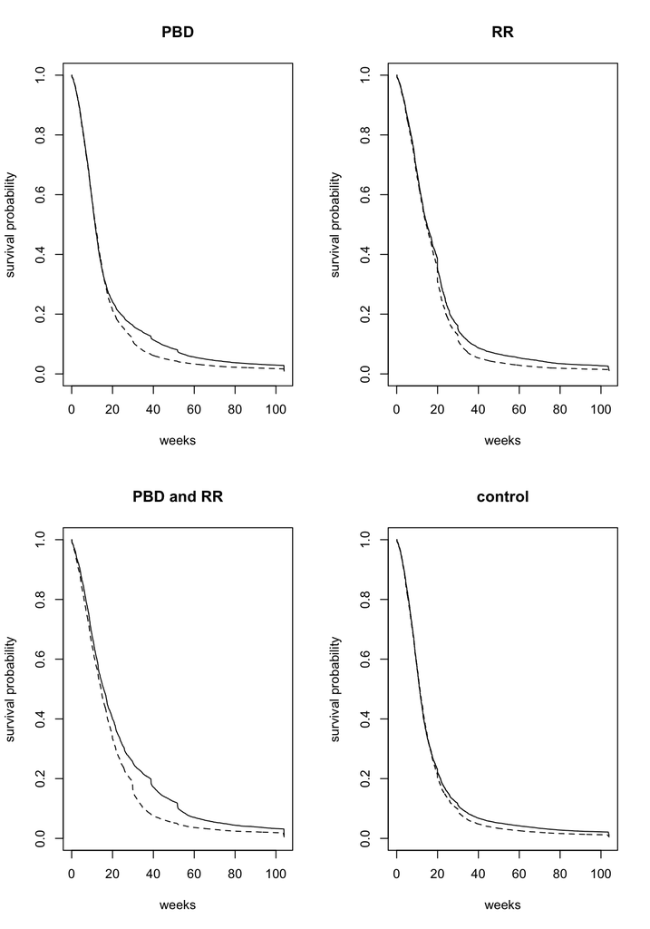

## 5.1 KM estimates of the unemployment exit hazard

Lalive et al. (2006) also report in Figure 4 hazard estimates based on the KM estimates. It is not quite clear how these have been generated, since these figures are very smooth.

One way of proceeding it to estimate the hazard as

$$\hat{\lambda}(t) = \frac{\hat{f}(t)}{\hat{S}(t)}$$
If we use the discrete approximation to $f$ based on $\hat{S}(t)$, this will be very erratic. One way to increase smoothness is to pick a smaller number of points on $\hat{S}(t)$, e.g. one for each week.

- **Q4** (KM estimates of the unemployment exit hazard): Seek to reproduce Figure 4 in Lalive et al. (2006).

Using `KernSmooth::locpoly` (as in our empirical exercises), my smoothed version is:

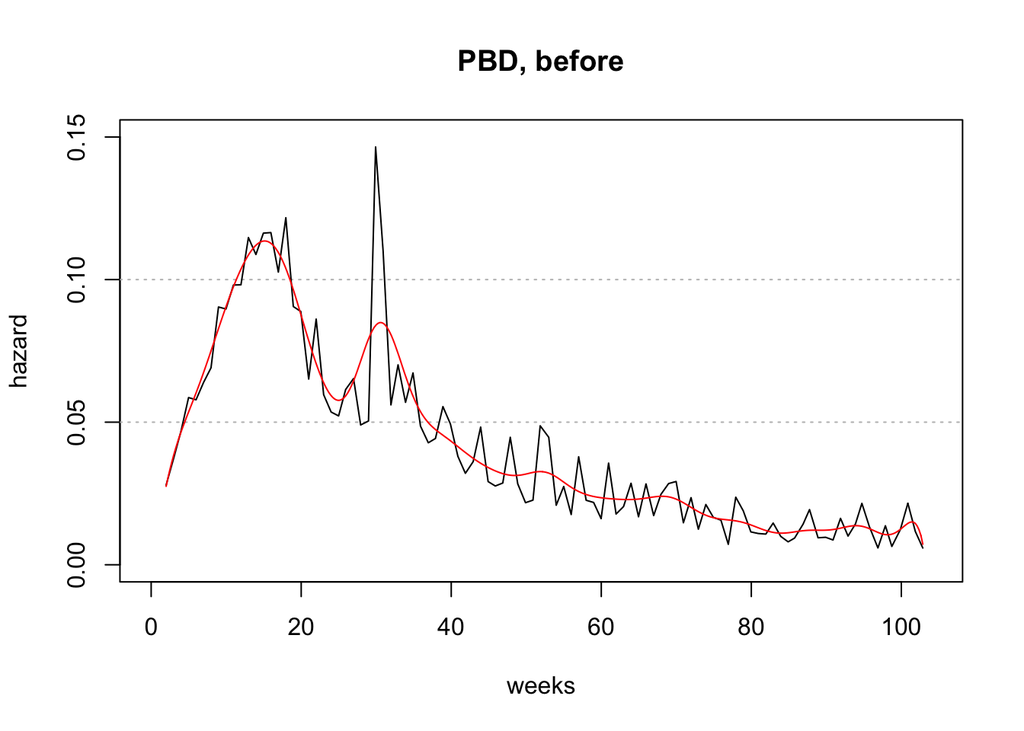

My approximate replication of Figure 4 then is

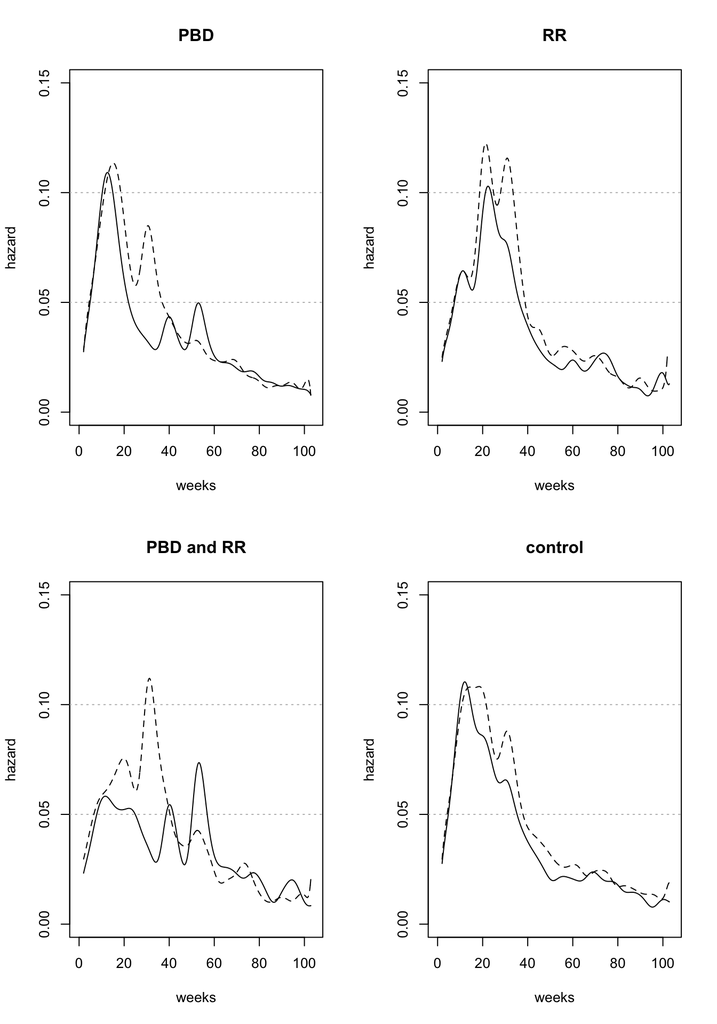

# 6 Estimating the causal treatment effect in a PH model

The authors estimate a PH model, $\lambda_0(t) \exp(x'\beta)$, where the baseline hazard is the key object of interest (since it refers to the exit rate for a homogeneous group of workers). Specifically, it is specified as a piecewsie constant function, where shift can occur in every four-week interval.

$$\lambda_0 (t) \ exp \left( \sum_{l=i} ^{14} \lambda_l I (4l < t < 4(l+1) +
\lambda_{15} I(t > 60) \right)$$
The trick is in specifying the coefficients $\lambda$ so as to allow policy changes to have an effect

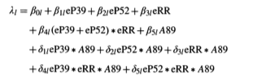

If your computer has insufficient RAM, take a random sample before preparing the PH model estimation.

Then split the data as per usual in order to estimate the PWE PH model:

```r
udat %>%
  mutate(all = tr * (t39 + t52) ) ->
  udat

breaks <- seq(from=3,to=59, by=4)
labels <- paste("(", c(0,breaks), ",", c(breaks,104), "]",sep="")

gux <- survSplit(Surv(dur104,uncc) ~., data=udat, cut = breaks,
                 end = "time", event="death", start="start", episode="interval")

gux %>%
  mutate(exposure = time - start,
        interval=factor(interval+1, labels = labels) ) ->
  gux
```

- **Q5** Estimate the causal treatment effect in a PH model.

Estimating the PWE model will take a few minutes given the size of the data (about 5’ on my laptop).

The first few coefficients in my implementation are as follows:

```r
library(stargazer)

stargazer(pwe,
          dep.var.caption="",dep.var.labels="",
          keep=1:15,
          omit.table.layout = "n", star.cutoffs = NA,
          keep.stat=c("n", "ll"),no.space=TRUE,
          header=FALSE,
          title="The PWE model", type="text"
          )
```

```
##
## The PWE model
## =============================
##
## -----------------------------
## interval(3,7]       0.646
##                    (0.015)
## interval(7,11]      1.163
##                    (0.015)
## interval(11,15]     1.401
##                    (0.016)
## interval(15,19]     1.334
##                    (0.018)
## interval(19,23]     1.469
##                    (0.019)
## interval(23,27]     1.209
##                    (0.023)
## interval(27,31]     1.256
##                    (0.025)
## interval(31,35]     1.091
##                    (0.031)
## interval(35,39]     0.791
##                    (0.039)
## interval(39,43]     0.627
##                    (0.045)
## interval(43,47]     0.442
##                    (0.053)
## interval(47,51]     0.253
##                    (0.061)
## interval(51,55]     0.222
##                    (0.065)
## interval(55,59]     0.129
##                    (0.072)
## interval(59,104]    0.291
##                    (0.029)
## -----------------------------
## Observations      1,057,906
## Log Likelihood   -686,532.500
## =============================
```

The coefficient estimates are reported by Lalive et al. in the separately posted document entitled `lalive coeff estimates PH appendixtable.pdf`.